# L17 - Intro to Classification

## Lecture Goals

- Perform binary classification w/ thresholding
- Measure classifier performance using
  - *Confusion matrix*
  - *ROC* curves
- Readings:
  - [ISLR](http://www-bcf.usc.edu/~gareth/ISL/) ch. 4.1

## Wisconsin Diagnostic Breast Cancer (WDBC) Data

- Fine-Needle Aspiration (FNA) data on 569 patients
  - 212 w/ malignant & 357 w/ benign tumors
  - (available from UCI data repository):
- FNA biopsy withdraws small amount of tissue/fluid from suspicious area
  - Biopsy sample checked for cancer cells

## WDBC Data

- Calculate tumor cell *features* based on FNA images

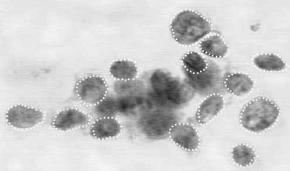

## WDBC Features

- For each cell, calculate
  1. *radius* (mean distance from center to perimeter)
  2. *texture* (standard deviation of gray-scale values)
  3. *perimeter*
  4. *area*
  5. *smoothness* (local variation in radius lengths)
  6. *compactness* (perimeter^2 / area - 1.0)
  7. *concavity* (severity of concave portions of contour)
  8. *concave points* (number of concave portions of contour)
  9. *symmetry*
  10. *fractal dimension*

## WDBC Features

- For each image (group of cells) report
  1. *mean* (`.m`)
  2. *standard deviation* (`.se`)
  3. *worst* value (`.w`)
- In total, 3 x 10 = 30 features

## WDBC Data

```r
wdbc = read_csv("data/wdbc.csv")
glimpse(wdbc)
```

```
## Observations: 569
## Variables: 32
## $ id             <dbl> 842302, 842517, 84300903, 84348301, 84358402, 8...
## $ diagnosis      <chr> "M", "M", "M", "M", "M", "M", "M", "M", "M", "M...
## $ radius.m       <dbl> 17.990, 20.570, 19.690, 11.420, 20.290, 12.450,...
## $ radius.se      <dbl> 10.38, 17.77, 21.25, 20.38, 14.34, 15.70, 19.98...
## $ radius.w       <dbl> 122.80, 132.90, 130.00, 77.58, 135.10, 82.57, 1...
## $ texture.m      <dbl> 1001.0, 1326.0, 1203.0, 386.1, 1297.0, 477.1, 1...
## $ texture.se     <dbl> 0.11840, 0.08474, 0.10960, 0.14250, 0.10030, 0....
## $ texture.w      <dbl> 0.27760, 0.07864, 0.15990, 0.28390, 0.13280, 0....
## $ perimeter.m    <dbl> 0.30010, 0.08690, 0.19740, 0.24140, 0.19800, 0....
## $ perimeter.se   <dbl> 0.14710, 0.07017, 0.12790, 0.10520, 0.10430, 0....
## $ perimeter.w    <dbl> 0.2419, 0.1812, 0.2069, 0.2597, 0.1809, 0.2087,...
## $ area.m         <dbl> 0.07871, 0.05667, 0.05999, 0.09744, 0.05883, 0....
## $ area.se        <dbl> 1.0950, 0.5435, 0.7456, 0.4956, 0.7572, 0.3345,...
```

[output cut: 19 more lines]

## Classification

- Create system that predicts *label* \(Y\) based on *feature* variables \(X_1, \ldots, X_p\)
  - Called *binary* classification when \(Y\) takes only 2 values
- Find function \(f(\cdot)\) such that \(f(X_1,...,X_p) = \hat{Y} \sim Y\)

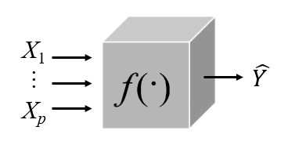

- Several methods to arrive at \(f(\cdot)\)
  - some work better than others on certain problems

## Threshold Classification

- Mean cell smoothness is indicative of cancer

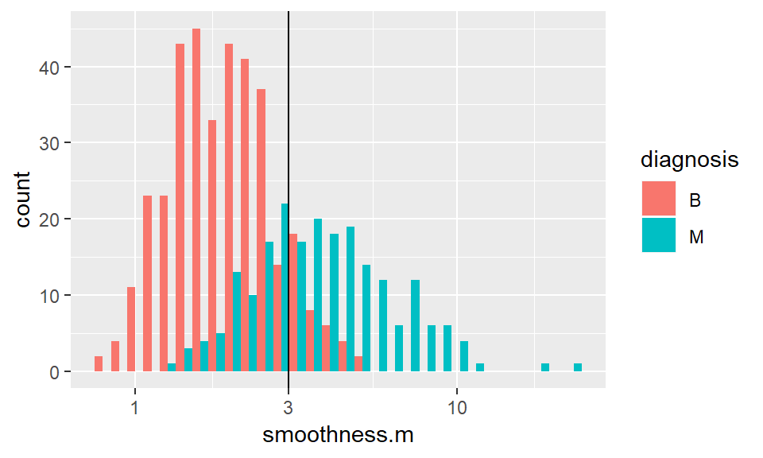

```r
wdbc %>% ggplot(aes(x = smoothness.m, fill = diagnosis )) +
  geom_histogram(position = "dodge", bins=30) +
  geom_vline(xintercept = 3) + scale_x_log10()
```

## Classification Accuracy

- **Accuracy**: proportion of *correct* predictions
  - Does not differentiate classes (all equally important)
- Compare to *naive* majority classifier
  - For WDBC, predict benign

```r
wdbc %>% mutate( naive = "B",
  predicted = ifelse( smoothness.m > 3, "M", "B")) %>%
  summarise( acc.pred = mean(predicted == diagnosis),
             acc.naiv = mean(naive == diagnosis) )
## # A tibble: 1 x 2
##   acc.pred acc.naiv
##      <dbl>    <dbl>
## 1    0.805    0.627
```

## Confusion Matrix

- [**Confusion matrix**](https://en.wikipedia.org/wiki/Confusion_matrix) is more nuanced performance measure
  - Assuming class of interest is *positive*

|  | Actual Positive | Actual Negative | Sum |
| --- | --- | --- | --- |
| Predict Positive | True Positive (\(TP\)) | False Positive (\(FP\)) | \(PP = TP+FP\) |
| Predict Negative | False Negative (\(FN\)) | True Negative (\(TN\)) | \(PN = FN + TN\) |
| Sum | \(P = TP + FN\) | \(N = FP+TN\) |  |

- What would be Type I/II Error in hypothesis testing?

## Confusion Matrix

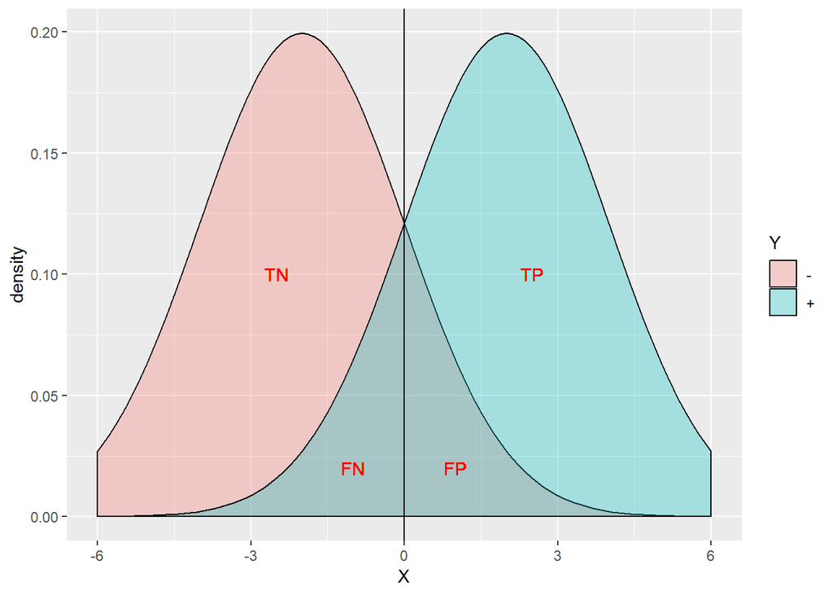

## Example

```r
wdbc %>%
  mutate( predicted = ifelse( smoothness.m > 3, "M", "B") ) %>%
  mutate( predicted = fct_relevel(predicted, "M"),
          diagnosis = fct_relevel(diagnosis, "M") ) %>%
  xtabs( ~ predicted + diagnosis, data = .) %>% addmargins()
##          diagnosis
## predicted   M   B Sum
##       M   140  39 179
##       B    72 318 390
##       Sum 212 357 569
```

## Classifier Performance

- **Sensitivity/Recall/True Positive Rate (TPR)**: \(TP/P\)
- **Precision/Positive Predictive Value (PPV)**: \(TP/PP\)
- **Specificity/True Negative Rate (TNR)**: \(TN/N\)
- **False Positive Rate (FPR)**: = \(FP / N = 1-TNR\)
- **F1-measure**: \(2\frac{ Sens. \times Prec.}{Sens. + Prec.}\)
  - Closer to 1 is better

## ROC curve

- **ROC curve**: plot of FPR vs TPR for *all possible thresholds* (configurations) of binary classifier

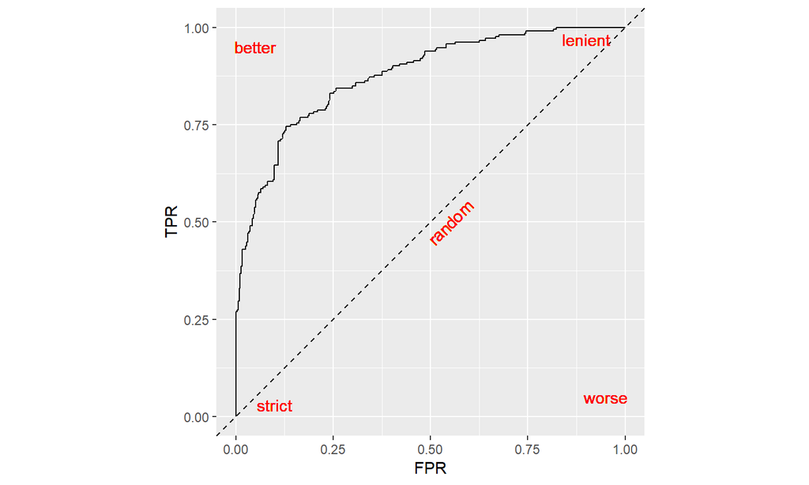

## Example

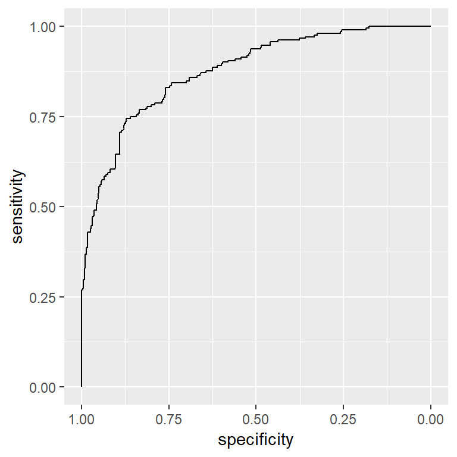

```r
library(pROC)
ROC_out = roc(diagnosis ~ smoothness.m,  data = wdbc)
ggroc(ROC_out)
```

## ROC curve

- Classifiers with ROC curve *above and to the left* are *better*
  - Compare classifiers *irrespective* of threshold
  - Difficult to compare curves that cross
- *Area under curve* (AUC) used as a proxy for classifier performance

```r
auc(diagnosis ~ smoothness.m,  data = wdbc) # auc(ROC_out)
```

```
## Area under the curve: 0.8764
```